# Week 4 Assignment

Andrea Staten

09/14/2025

For this assignment, we are going to use data from the Elementary/Secondary Information System (ElSi). ELSi simplifies downloading data from the Common Core of Data (CCD) and Private School Survey (PSS).

## Step 1

Load the necessary packages: tidyverse and janitor

```r
library(tidyverse)
library(janitor)
```

## Step 2

Load ELSI data. You will need to give the dataframe a name to make R “store” it for later use.

```r
elsi <- read_csv("elsi-data.csv", skip = 6)
# This .csv has 6 rows of information before the data starts. We must tell R to skip the 6 rows of information in order for the data to import correctly. To do this, we include "skip = 6" after the file name.
```

## Step 3

Explore the data and clean column names as necessary using `clean_names()`

```r
glimpse(elsi)
```

```
## Rows: 114,620
## Columns: 28
## $ `School Name`                                                      <chr> "`F…
## $ `State Name [Public School] Latest available year`                 <chr> "Ne…
## $ `Locale [Public School] 2021-22`                                   <chr> "21…
## $ `Locale [Public School] 2011-12`                                   <chr> "21…
## $ `Magnet School [Public School] 2021-22`                            <dbl> NA,…
## $ `Magnet School [Public School] 2011-12`                            <dbl> NA,…
## $ `Charter School [Public School] 2021-22`                           <dbl> 2, …
## $ `Charter School [Public School] 2011-12`                           <dbl> 2, …
## $ `School-wide Title I [Public School] 2021-22`                      <dbl> 2, …
## $ `School-wide Title I [Public School] 2011-12`                      <dbl> 2, …
## $ `Total Students All Grades (Excludes AE) [Public School] 2021-22`  <dbl> 842…
## $ `Total Students All Grades (Excludes AE) [Public School] 2011-12`  <dbl> 106…
## $ `American Indian/Alaska Native Students [Public School] 2021-22`   <dbl> 2, …
## $ `American Indian/Alaska Native Students [Public School] 2011-12`   <dbl> 0, …
## $ `Asian or Asian/Pacific Islander Students [Public School] 2021-22` <dbl> 30,…
## $ `Asian or Asian/Pacific Islander Students [Public School] 2011-12` <dbl> 21,…
## $ `Hispanic Students [Public School] 2021-22`                        <dbl> 594…
## $ `Hispanic Students [Public School] 2011-12`                        <dbl> 622…
## $ `Black or African American Students [Public School] 2021-22`       <dbl> 15,…
## $ `Black or African American Students [Public School] 2011-12`       <dbl> 26,…
## $ `White Students [Public School] 2021-22`                           <dbl> 189…
## $ `White Students [Public School] 2011-12`                           <dbl> 389…
## $ `Total Race/Ethnicity [Public School] 2021-22`                     <dbl> 842…
## $ `Total Race/Ethnicity [Public School] 2011-12`                     <dbl> 106…
## $ `Full-Time Equivalent (FTE) Teachers [Public School] 2021-22`      <dbl> 82.…
## $ `Full-Time Equivalent (FTE) Teachers [Public School] 2011-12`      <dbl> 82.…
## $ `Pupil/Teacher Ratio [Public School] 2021-22`                      <dbl> 10.…
## $ `Pupil/Teacher Ratio [Public School] 2011-12`                      <dbl> 12.…
```

```r
print(elsi)
```

```
## # A tibble: 114,620 × 28
##    `School Name`                   State Name [Public S…¹ Locale [Public Schoo…²
##    <chr>                           <chr>                  <chr>
##  1 `FRANKLIN ELEMENTARY SCHOOL     New Jersey             21-Suburb: Large
##  2 1 LT CHARLES W. WHITCOMB SCHOOL Massachusetts          21-Suburb: Large
##  3 100 ACADEMY OF ENGINEERING AND… Nevada                 21-Suburb: Large
##  4 100 ACADEMY OF ENGINEERING AND… Nevada                 21-Suburb: Large
##  5 100 LEGACY ACADEMY CHARTER SCH… New Jersey             <NA>
##  6 10TH STREET SCHOOL              Washington             22-Suburb: Mid-size
##  7 112 ALC INDEPENDENT STUDY       Minnesota              21-Suburb: Large
##  8 112 ALC MIDDLE SCHOOL           Minnesota              21-Suburb: Large
##  9 112 ALC SEAT-BASED              MINNESOTA              21-Suburb: Large
## 10 114-E-W-4                       FLORIDA                11-City: Large
## # ℹ 114,610 more rows
## # ℹ abbreviated names: ¹`State Name [Public School] Latest available year`,
## #   ²`Locale [Public School] 2021-22`
## # ℹ 25 more variables: `Locale [Public School] 2011-12` <chr>,
## #   `Magnet School [Public School] 2021-22` <dbl>,
## #   `Magnet School [Public School] 2011-12` <dbl>,
## #   `Charter School [Public School] 2021-22` <dbl>, …
```

```r
elsi_clean <- clean_names(elsi) # Rename the clean names version of the dataframe. It can be the same name or something new.
```

## Step 4a

Create a bar plot looking at the number of Title 1 schools in the 2021-22 school year. *Notes*: the value of 1 means the school is a Title 1 school and the value of 2 means the school is not a Title 1 school. Also, we are using a bar graph because the data is categorical – either a school is Title 1 or it is not.

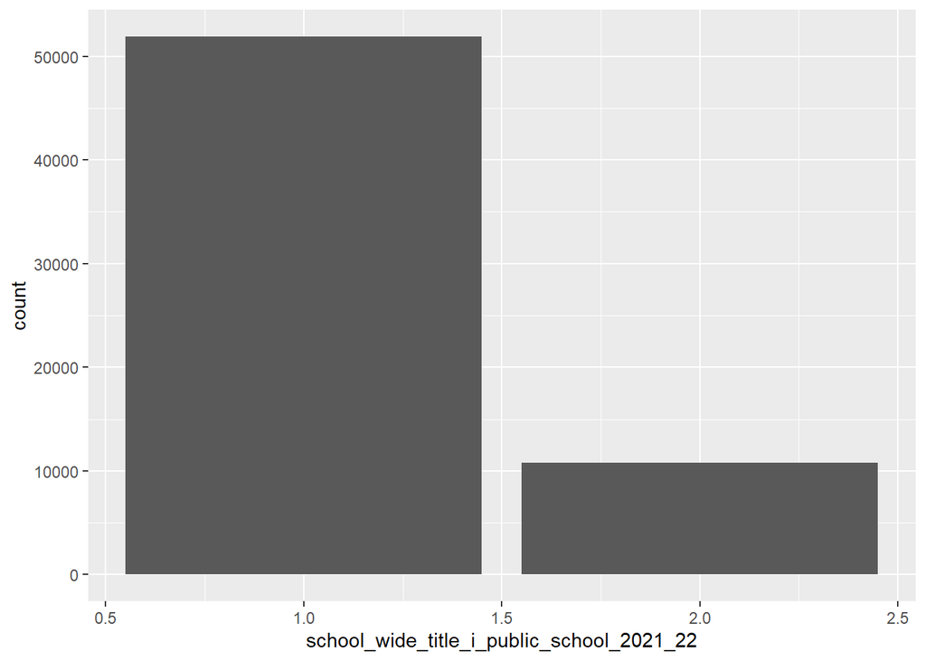

```r
elsi_clean %>%
    ggplot(aes(x = school_wide_title_i_public_school_2021_22)) +
    geom_bar()
```

- Approximately how many schools were Title 1? How many were not? There were approximately 50,000 Title 1 schools, and 10,000 that were not.

## Step 4b

We can also change the theme of the plot and make the colors a bit more interesting.

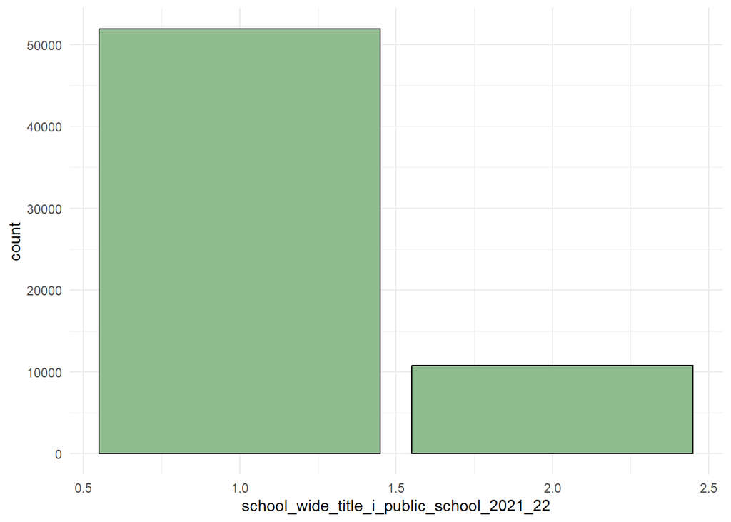

```r
elsi_clean %>%
    ggplot(aes(x = school_wide_title_i_public_school_2021_22)) +
    geom_bar(fill = "darkseagreen", color = "black") +
    theme_minimal()
```

```r
# Notes: fill changes the "inside" color of the bars while color changes the border color of the bars.
# There are many themes you can select (https://ggplot2.tidyverse.org/reference/ggtheme.html).
# There are many colors you can select (https://www.datanovia.com/en/blog/awesome-list-of-657-r-color-names/)
```

## Step 5

Create a histogram to examine the total number of students in schools for the 2021-22 school year.

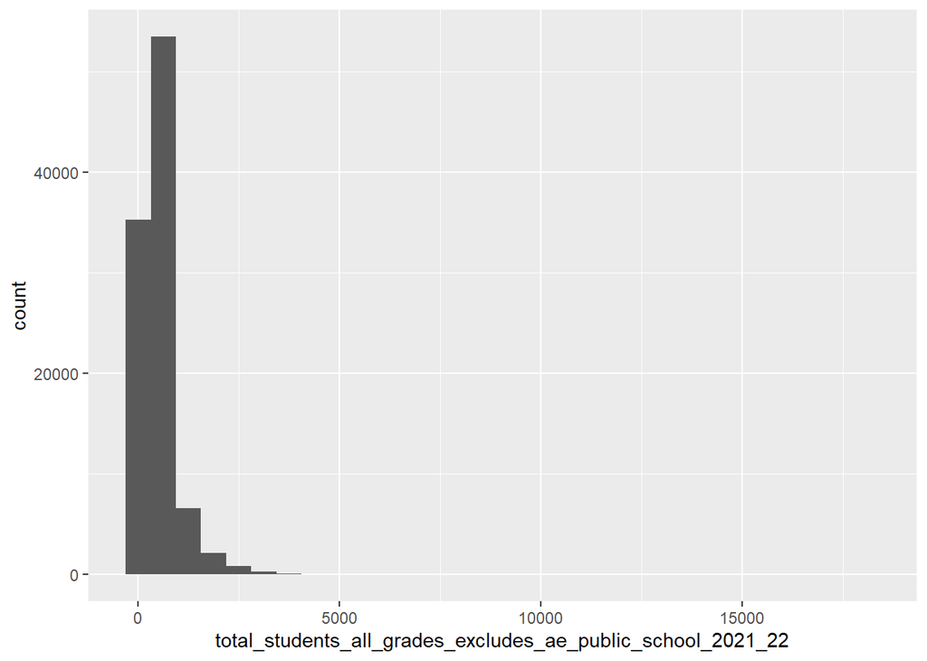

```r
elsi_clean %>%
    ggplot(aes(x = total_students_all_grades_excludes_ae_public_school_2021_22)) +
    geom_histogram()
```

With the default bin width and the maximum x-value of 20,000, the plot is not very interesting. We can change these two defaults quite easily:

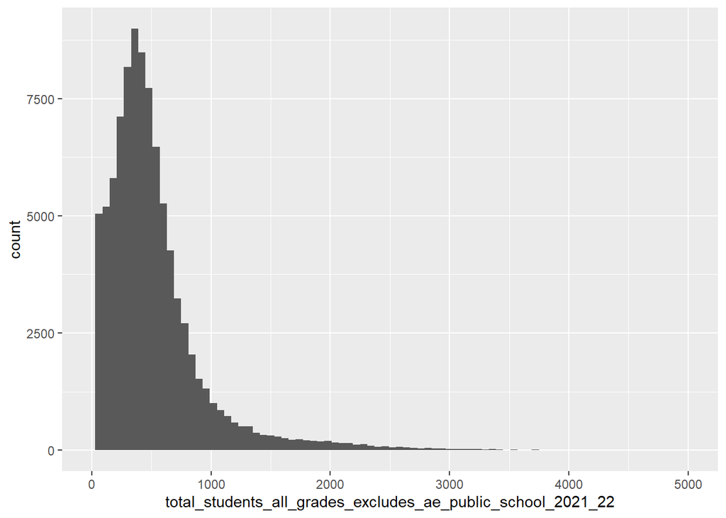

```r
elsi_clean %>%
    ggplot(aes(x = total_students_all_grades_excludes_ae_public_school_2021_22)) +
    geom_histogram(binwidth = 60) +
    xlim(0, 5000)
```

```r
# You should select a bin width that best tells the story of your data.
```

## Step 5b

Just as we did with the bar chart, we can also change the theme and colors of the histogram.

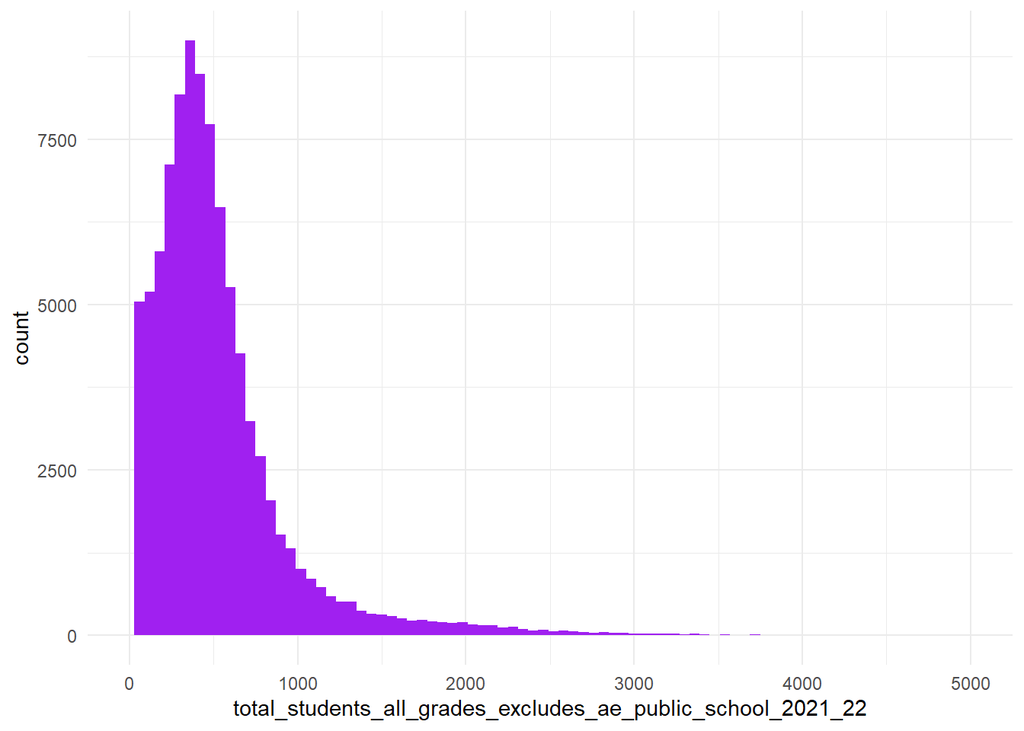

```r
elsi_clean %>%
    ggplot(aes(x = total_students_all_grades_excludes_ae_public_school_2021_22)) +
    geom_histogram(fill = 'purple', binwidth = 60) +
    theme_minimal() +
    xlim(0, 5000)
```

## Step 6

Create a histogram comparing multiple groups. Use ggplot2 and `facet_wrap()`. When you put $ after your data frame, it displays the names of its columns (press tab to see the list of columns). Select an appropriate column to use facet_wrap functions for comparing multiple groups.

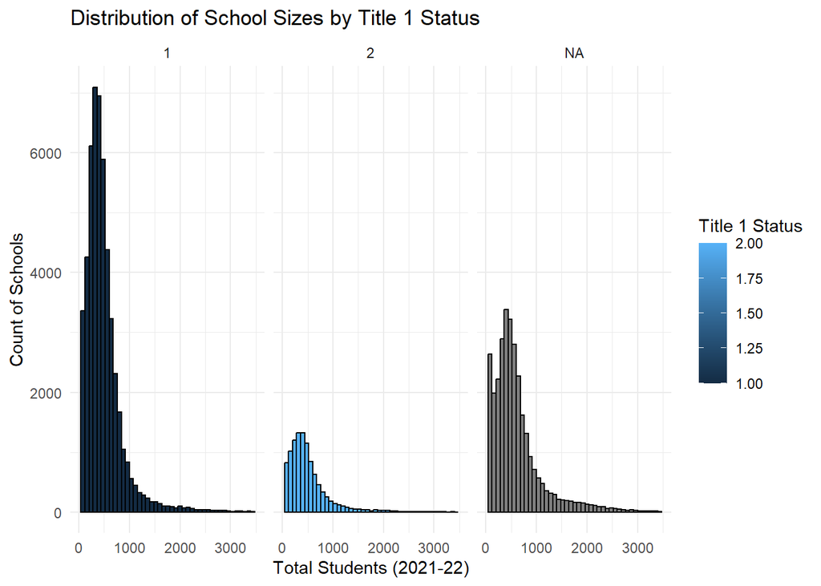

```r
elsi_clean %>%
    ggplot(aes(x = total_students_all_grades_excludes_ae_public_school_2021_22, fill = school_wide_title_i_public_school_2021_22)) +
    geom_histogram(binwidth = 80, color = 'black') +
    xlim(0,3500) +
    facet_wrap(elsi_clean$school_wide_title_i_public_school_2021_22) +
    theme_minimal() +
    labs(
      x = "Total Students (2021-22)",
      y = "Count of Schools",
      fill = "Title 1 Status",
      title = "Distribution of School Sizes by Title 1 Status"
    )
```

## Reach

This portion of the assignment is optional but offers you a chance to push your skills further.

- Change the theme and color for your graphs in Step 6. Can you color each graph by the variable you are faceting on?

## Rubric

|  | Points Possible | Points Earned |
| --- | --- | --- |
| File knits | 2 |  |
| Effective use of `facet_wrap()` | 10 |  |
| Question 1 | 5 |  |
| Question 2 | 8 |  |
| Question 3 | 5 |  |

## Knit and Submit

Complete the following steps to knit and publish your work:

1. First, change the name of the `author:` in the [YAML header](https://bookdown.org/yihui/rmarkdown-cookbook/rmarkdown-anatomy.html#yaml-metadata) at the very top of this document to your name. The YAML header controls the style and feel for knitted document but doesn’t actually display in the final output.
2. Next, click the knit button in the toolbar above to “knit” your R Markdown document to a [HTML](https://bookdown.org/yihui/rmarkdown/html-document.html) file that will be saved in your R Project folder. You should see a formatted webpage appear in your Viewer tab in the lower right pan or in a new browser window. Let’s us know if you run into any issues with knitting.
3. Upload the HTML file that is now present in the same folder as this R Markdown file to Canvas to receive credit for this assignment!